# BIOS 591R - 2019 - Lecture 8: Graphics I: base graphics

Ziyi Li <ziyi.li@emory.edu>

### Content today

- Features and history of R graphics
- Brief overview of BASE graphics

### Features of R graphics

- R has a powerful environment for visualization of scientific data
- It provides publication quality graphics, which are fully programmable
- Easily reproducible
- Full LaTeX and Sweave support
- Lots of packages and functions with built-in graphics support
- On-screen graphics
- Postscript, PDF, jpeg, png, SVG

### History of R graphics

- R Graph Gallery
  - https://www.r-graph-gallery.com/network/
- R Graphic Manual and Gallery
  - https://www.imsbio.co.jp/RGM/R_image_list?page=277&init=true
- Grid Graphics - Paul Murrell
  - https://stat.ethz.ch/R-manual/R-devel/library/grid/doc/grid.pdf
- Lattic Graphics
  - http://lattice.r-forge.r-project.org/Vignettes/src/lattice-intro/lattice-intro.pdf
- ggplot2 - Tidyverse
  - https://ggplot2.tidyverse.org/

### History of R graphics

R graphics can be confusing because there are no less than 4 different systems. Let's list them out here and talk about which one(s) to use.

**Low-Level Capability**

- Base Graphics (Has Low and High Level functions)
- Grid Graphics

**High-Level Capability**

- Lattice Graphics
- ggplot2

### History: BASE graphics

- Oldest and most commonly used
- Uses a “pen-on-paper” model. You can only draw on top of the object. Cannot erase, modify, or delete what has already been drawn. Mimicing the thinking process.
- Has both high and low level plotting routines (unique to Base)
- Base graphics are fast.
- Lots of documentation and “google” support

### BASE graphics

[figure not shown]

### History: Grid graphics

- Developed in 2000 by Paul Murrell
- Provides a rich set of graphics primitives
- Uses a system of objects and view ports to make complex objects easier.
- You will almost never use this directly unless you want to do in-depth programming

### Grid graphics

[figure not shown]

### History: Lattice package

- Developed by Deepayan Sarkar to implement the trellis graphics system described in “Visualizing Data” by Cleveland.
- Independent from the BASE graphics. Include its own functions such as `xyplot`, `bwplot`, `levelplot`
- Easy to create conditioned plots with automatic creation of axes, legends, and other annotations
- Usually considered to be an improvement over Base graphics.

### Lattice package

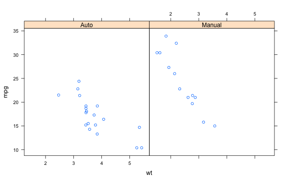

```r
library(lattice)
xyplot(mpg~wt | factor(am,labels=c("Auto","Manual")), data=mtcars)
```

### History: ggplot2

- Developed starting in 2005 by Hadley Wickham
- ggplot2 is an implementation of Leland Wilkinson's Grammar of Graphics–a general scheme for data visualization which breaks up graph into semantic components such as scales and layers.
- ggplot2 can serve as a replacement for the base graphics in R and contains a number of defaults for web and print display of common scales.
- Is said to be much slower than Base graphics but this isn't a major thing (in my opinion)
- Part of Tidyverse

### ggplot2

[figure not shown]

# **BASE Graphics**

### Brief overview of BASE graphics

[figure not shown]

### Brief overview of BASE graphics

[figure not shown]

### Brief overview of BASE graphics

[figure not shown]

### Brief overview of BASE graphics

[figure not shown]

### Brief overview of BASE graphics

[figure not shown]